# SOK-1004, Produksjon med ggplot2

Author

Derek J. Clark

# 1. Produksjonsisokvanter

Vi skal se på en bedrift som produserer et produkt ved å kombinere arbeidskraft (L) og kapital (K) i en Cobb-Douglas produktfunksjon:

$$Y(K,M)=AL^aK^b\hspace{1cm}(1)$$

Her er $a>, b>0$ produksjonselastisiteter (se forelesning 8). $A>0$ er en konstant.

En isokvant som gir produksjonsnivå $Y_0$ defineres som

$$Y_0=AL^aK^b\hspace{1cm}(2)$$

La oss bruke `ggplot2` til å tegne noen isokvanter. Først må vi skrive om (2):

$$K^b=\frac{Y_0}{AL^a}\\
\Rightarrow (K^b)^\frac{1}{b}=\left(\frac{Y_0}{AL^a}\right)^\frac{1}{b}\\
\Rightarrow K=\frac{Y_0^{\frac{1}{b}}}{A^{\frac{1}{b}}L^{\frac{a}{b}}} \hspace{1cm} (3)$$

I det videre skal vi anta at $A=5, a=\frac{1}{2}, b=\frac{1}{2}$, slik at (3) skrives

$$K=\frac{Y_0^2}{25L} \hspace{1cm} (4)$$

Følgende kode tegner tre isokvanter for produksjonsnivåene 20, 40 og 60 enheter

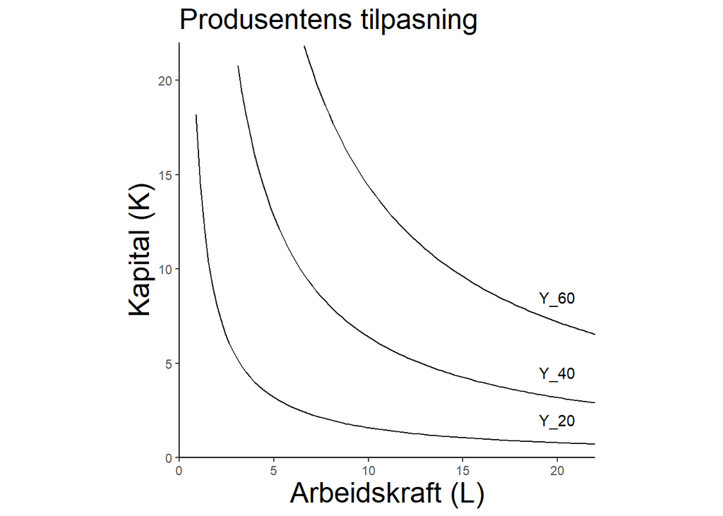

```r
rm(list = ls())

suppressPackageStartupMessages(library(tidyverse))


# vi lager oss noen tall for x-variabelen (L)

x <- seq(0, 21, by = .1)

# gjør om til data frame

df <- data.frame(x)

#lag aksen for tegningen

axes_1 <- ggplot(df, aes(x))+
  labs(title="Produsentens tilpasning",
    x="Arbeidskraft (L)",
    y="Kapital (K)")+
  theme(axis.title = element_text(size = 20),
        plot.title = element_text(size = 20),
        panel.background = element_blank(),  # få hvit bakgrunn
        axis.line = element_line(colour = "black"))+  # tegne linje for aksene
  coord_fixed(ratio = 1)+ # sikre at skale for x og y er samme
  scale_x_continuous(limits = c(0, 22), expand = c(0, 0))+
  scale_y_continuous(limits = c(0, 22), expand = c(0, 0)) # begrense aksene
# samt sikre at akselinjene begynner 9 (0,0)

# vi angir noen isokvanter

Y_20 <- function(x) (20^2)/(25*x)
Y_40 <- function(x) (40^2)/(25*x)
Y_60 <- function(x) (60^2)/(25*x)

figur_1 <- axes_1 +
  stat_function(df,
        fun=Y_20,
        mapping = aes()) +
  stat_function(df,
                fun=Y_40,
                mapping = aes()) +
  stat_function(df,
                fun=Y_60,
                mapping = aes())+
  annotate("text", x=20,y=2, label="Y_20")+
  annotate("text", x=20,y=4.5, label="Y_40")+
  annotate("text", x=20,y=8.5, label="Y_60")

figur_1
```

# 2. Isokostnadslinjer

En isokostnadslinje for $k_0$ kr er gitt ved

$$k_0=wL+rK \Rightarrow K=\frac{k_0}{r}-\frac{w}{r}L \hspace{1cm} (5)$$

og viser kombinasjoner av $L, K$ som koster $k_0$ kr. Vi ser at $\frac{w}{r}$ angir den relative prisen på arbeidskraft. Anta at prisen på arbeidskraft er $w=2$, og prisen på kapital er $r=1$, slik at (5) skrives

$$K=k_0-2L\hspace{1cm} (6)$$

La oss legge isokostnadslinjer på figuren med isokvantene.

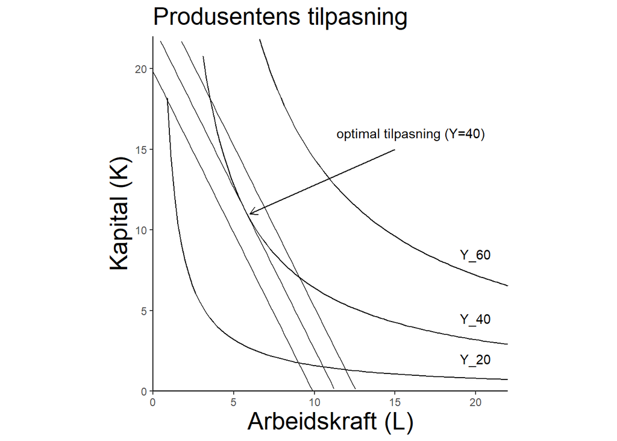

```r
iso_19.8 <- function(x) 19.8-2*x
iso_22.6 <- function(x) 22.6-2*x
iso_25.2 <- function(x) 25.2-2*x
figur_2 <- figur_1+
  stat_function(df, fun=iso_19.8, mapping = aes())+
  stat_function(df, fun=iso_22.6, mapping = aes())+
  stat_function(df, fun=iso_25.2, mapping = aes())+
  geom_segment(aes(x=15, y=15, xend=6, yend=11),
               arrow = arrow(length = unit(0.25, "cm")))+
  annotate("text",x=16,y=16,
           label="optimal tilpasning (Y=40)")



figur_2
```

# 3. Produsentens tilpasning

Anta at produsenten vil lage 40 enheter til lavest kostnad. For å lage 40 enheter må produksjon finne sted på isokvanten merket $Y_{40}$ , og lavest kostnad innebærer at vi er på en isokostnadslinje nærmest origo. Dette gir et tangeringspunkt mellom isokvanten og isokostnadslinjen som merket i figuren.

Figuren under viser tilsvarende tilpasning for 20 produserte enheter (hvordan dette regnes ut vil dere lære i sok-1006 Mikroøkonomi).

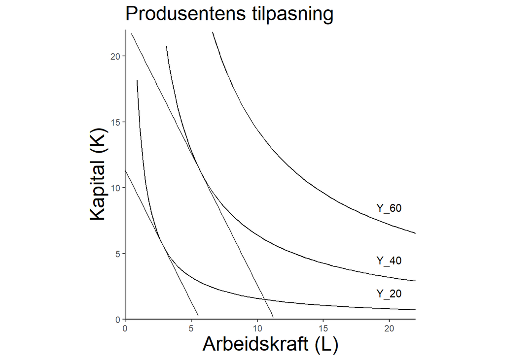

```r
iso_11.31 <- function(x) 11.31-2*x

figur_3 <- figur_1+
  stat_function(df, fun=iso_11.31, mapping = aes())+
  stat_function(df, fun=iso_22.6, mapping = aes())



figur_3
```

Legg merke til at arbeidskraft og kapital er like kraftfulle i produktfunksjonen. Eneste forskjell mellom innsatsfaktoren i denne oppgaven er fra den økonomiske siden - arbeidskraft er dobbelt så dyrt som kapital. Da børe det ikke være så overraskende at produsenten bruker dobbelt så mye kapital som arbeidskraft i dette eksempelet. Se figuren nedenfor som viser en stråle fra origo $K=2L$.

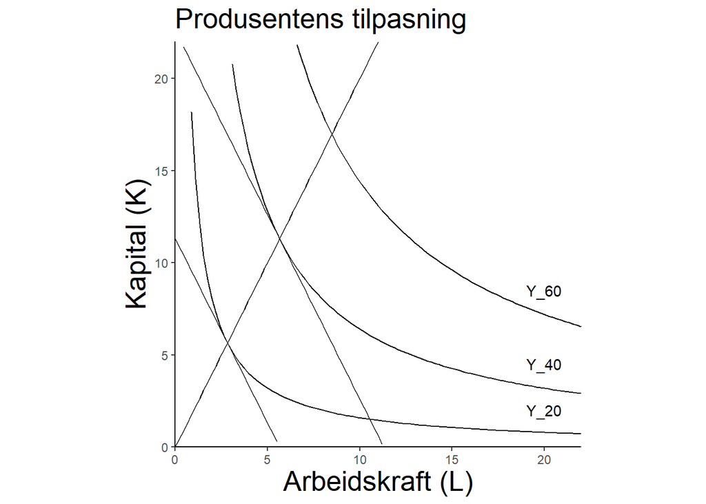

```r
optimal_1 <- function(x) 2*x

figur_4 <- figur_3+
  stat_function(df, fun=optimal_1, mapping = aes())



figur_4
```

# 4. Endring i relativ pris på innsatsfaktorene

Anta nå at prisen på kapital øker til $r=3$. Den nye tilpasningen for 20 enheter er vist i figuren nedenfor. Strålen fra origo er $K=\frac{2}{3}L$ som viser at bedriften nå bruker $\frac{2}{3}$ enheter kapital for hver enhet med arbeidskraft. Dette gjenspeiler den nye relative prisen på arbeidskraft som er blitt relativt billigere enn i utgangspunktet.

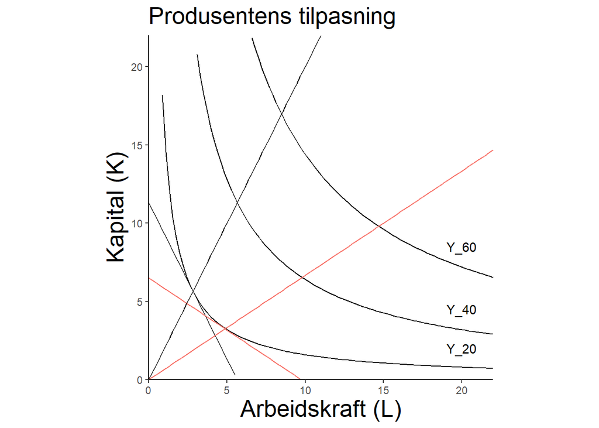

```r
optimal_2 <- function(x) (2/3)*x
ny_iso_6.5 <- function(x) 6.5-(2/3)*x

figur_5 <- figur_1+
  stat_function(df, fun=optimal_1, mapping = aes())+
  stat_function(df,  fun=iso_11.31, mapping = aes())+
  stat_function(df,fun=ny_iso_6.5, mapping = aes(col="red"),
                show.legend=FALSE)+
  stat_function(df,  fun=optimal_1, mapping = aes())+
  stat_function(df,fun=optimal_2, mapping = aes(col="red"),
                show.legend=FALSE)



figur_5
```